# Bootstrapped Difference in Timeseries

2022-08-01

# Introduction

- 2nd iteration of bdots
- will will discuss methodology, use, extensions

# Use

We now going into detail describing the reimplementation of bdots; that is, we will reintroduce how bdots works, along with significant changes made since the original package was created.

Probably a lot of stuff that you will want to do with bdots. Broadly, the bdots workflow can be described in two steps: fitting a parametric function to the data and finding bootstrapped differences between two groups. The current implementation has expanded on this in a number of ways, including the addition of generic functions for bdots objects, an interactive refitting step, as well as more general extensions to accomodate a range of non-vwp data.

## Fitting step

As before, the bdots workflow begins with identifying a parametric function to fit to the observed data. Two especially important functions in the context of the VWP are the four-parameter logistic and the six-parameter double Gaussian, both of which were included in the original implementation. The first of these is a sigmoid shaped curve, the other looks like a hump.

In contrast to the original implmentation, which provided a unique fitting function for each of the specified curves, bdots has now consolidated this process into a single function, `bdotsFit`, taking as one of its arguments the required parameteric curve.

```r
library(bdots)
bdotsFit(..., curveType = logistic())
```

Importantly, this allows the logic of the fitting function to be independent of the parametric function, allowing for the use of user-defined functions to take this role. This will be described in more detail in the ‘Extensions’ section.

For study designs in which individual subjects may be examined across a number of conditions, `bdotsFit` allows for an arbitrary number of groups to be fit at once, assuming that only a single curve is used. For example, we may be interested in comparing fixations to a specified target under a variety of conditions, each of which fit with the logistic curve.

```r
## Clean this up, obviously
load("~/packages/bdots/data/ci.rda")
ci <- as.data.table(ci)
ci <- ci[LookType == "Target", ]
fit <- bdotsFit(data = ci,
                subject = "Subject",
                time = "Time",
                y = "Fixations",
                group = "protocol",
                curveType = logistic())
```

The fitting function `bdotsFit` returns an object of class `bdotsObj`, inheriting from classes `data.table`. As such, this object can be manipulated and explored with standard `data.table` syntax. In addition to the subject and grouping columns, there is also a `fit` column, containing the fitted object from the `gnls` package, a column, `R2` with the R-squared value, a boolean column indicating `AR1` status, and finally a column for `fitCode`. We can see that here:

```r
head(fit)
```

```
##    Subject protocol        fit      R2  AR1 fitCode
## 1:       2       CI <gnls[18]> 0.99588 TRUE       0
## 2:       3       CI <gnls[18]> 0.99893 TRUE       0
## 3:       4       CI <gnls[18]> 0.99923 TRUE       0
## 4:       6       CI <gnls[18]> 0.99731 TRUE       0
## 5:      10       CI <gnls[18]> 0.99814 TRUE       0
## 6:      16       CI <gnls[18]> 0.99859 TRUE       0
```

The fit code is a numeric quantity representing the quality of the fit as such:

| fitCode | AR1 | R2 |
| --- | --- | --- |
| 0 | TRUE | R2 > 0.95 |
| 1 | TRUE | 0.8 < R2 < 0.95 |
| 2 | TRUE | R2 < 0.8 |
| 3 | FALSE | R2 > 0.95 |
| 4 | FALSE | 0.8 < R2 < 0.95 |
| 5 | FALSE | R2 < 0.8 |
| 6 | NA | NA |

A fit code of 6 indicates that a fit was unable to be made.

A `summary` function shows us the curve function used, and a breakdown, by group, of mean parameter values and quality of fitcode fits

```r
summary(fit)
```

```
##
## bdotsFit Summary
##
## Curve Type: logistic
## Formula: Fixations ~ mini + (peak - mini)/(1 + exp(4 * slope * (cross - (Time))/(peak - mini)))
## Time Range: (0, 2000) [501 points]
##
##
## protocol: CI
## Num Obs:  26
## Parameter Values:
##        mini        peak       slope       cross
##  -0.0212717   0.9385583   0.0018837 690.3436550
## ########################################
## ############### FITS ###################
## ########################################
## AR1,       0.95 <= R2        -- 26
## AR1,       0.80 < R2 <= 0.95 -- 0
## AR1,       R2 < 0.8          -- 0
## Non-AR1,   0.95 <= R2        -- 0
## Non-AR1,   0.8 < R2 <= 0.95  -- 0
## Non-AR1,   R2 < 0.8          -- 0
## No Fit                       -- 0
##
##
## protocol: NH
## Num Obs:  28
## Parameter Values:
##        mini        peak       slope       cross
##  -0.0215622   0.8733654   0.0014485 757.2417066
## ########################################
## ############### FITS ###################
## ########################################
## AR1,       0.95 <= R2        -- 28
## AR1,       0.80 < R2 <= 0.95 -- 0
## AR1,       R2 < 0.8          -- 0
## Non-AR1,   0.95 <= R2        -- 0
## Non-AR1,   0.8 < R2 <= 0.95  -- 0
## Non-AR1,   R2 < 0.8          -- 0
## No Fit                       -- 0
##
##
## All Fits
## Num Obs:  54
## Parameter Values:
##       mini       peak      slope      cross
##  -0.021422   0.904755   0.001658 725.031534
## ########################################
## ############### FITS ###################
## ########################################
## AR1,       0.95 <= R2        -- 54
## AR1,       0.80 < R2 <= 0.95 -- 0
## AR1,       R2 < 0.8          -- 0
## Non-AR1,   0.95 <= R2        -- 0
## Non-AR1,   0.8 < R2 <= 0.95  -- 0
## Non-AR1,   R2 < 0.8          -- 0
## No Fit                       -- 0
```

Because `bdotsObj` inherits from `data.table`, we are able to use `data.table` syntax for subsetting

```r
## Maybe find different things for this
head(coef(fit))
```

```
##           mini    peak     slope  cross
## [1,] -0.057616 0.79477 0.0008353 778.23
## [2,] -0.026808 0.97582 0.0018025 665.35
## [3,] -0.024878 0.91163 0.0015456 725.65
## [4,] -0.031117 0.75074 0.0010224 779.17
## [5,] -0.028972 0.85166 0.0012019 772.42
## [6,] -0.030064 0.85149 0.0011190 792.32
```

```r
head(coef(fit[protocol == "NH", ]))
```

```
##           mini    peak     slope  cross
## [1,] -0.016217 0.98057 0.0019558 691.21
## [2,] -0.017196 0.93682 0.0021694 679.87
## [3,] -0.016380 0.94873 0.0018173 715.19
## [4,] -0.019539 0.96423 0.0020362 615.54
## [5,] -0.021398 0.98272 0.0024508 681.95
## [6,] -0.039383 0.92636 0.0014237 670.31
```

In addition to `coef` and `summary`, the `plot` function will also demonstrate the fitted curves

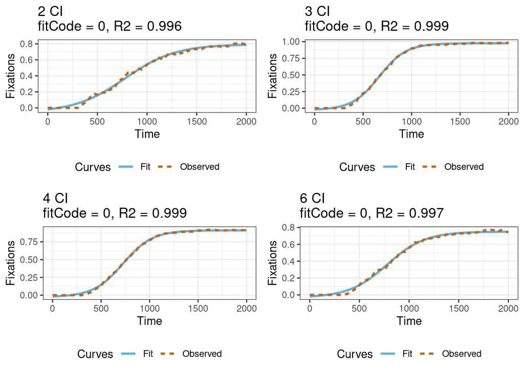

```r
plot(fit[1:4, ])
```

```r
## I feel like I should delete this from plot
# plot(fit, plotfun = "pars")
#
## Because I can do the same thing here
# par(mfrow = c(2,2))
# apply(coef(fit), 2, function(x) print(hist(x)))
```

## Bootstrapping

Once fits have been made, we are able to construct bootstrapped estimates of group level curves with `bdotsBoot`. Typically, we are interested in bootstrapping estimates of group level curves and determining the bootstrapped difference. In studies with nested conditions, however, we frequently find ourselves with the need to determine the difference between two difference curves (I think this is articulated somewhere else). For example, we may have two groups, $A$ and $B$, with two experimental conditions, $1$ and $2$. In determining the difference of difference curves, we may be interested in comparing the difference between groups $A$ and $B$ under condition $1$ with the difference between groups $A$ and $B$ in condition $2$. Or vice versa.

Note that matching subject identifiers between groups will indicate that a paired t-test is to be used. There is also `padj` that can be used to adjust ps. There are other, sensible parameters used

Finally, then, the bootstrapping function itself

```r
boot <- bdotsBoot(Fixations ~ protocol(CI, NH), fit, padj = "oleson")
summary(boot)
```

```
##
## bdotsBoot Summary
##
## Curve Type: logistic
## Formula: Fixations ~ mini + (peak - mini)/(1 + exp(4 * slope * (cross - (Time))/(peak - mini)))
## Time Range: (0, 2000) [501 points]
##
## Difference of difference: FALSE
## Paired t-test: FALSE
## Difference: protocol
##
## Autocorrelation Estimate: 0.99366
## Alpha adjust method: oleson
## Alpha:
## Adjusted alpha: 0.0020852
## Significant Intervals at adjusted alpha:
##      [,1] [,2]
## [1,]  416 2000
```

From this, we see that the summary returns a collection of relevant information, including the curve type, paired t-test status, autocorrelation estimate, the adjusted alpha. Relevant bits can be harvested from the `bdBootObj` itself,

```r
names(boot)
```

```
##  [1] "curveList"   "alpha"       "adjalpha"    "adjpval"     "sigTime"
##  [6] "rho"         "paired"      "diffs"       "curveGroups" "dod"
## [11] "curveFun"
```

# Extensions

There are several additions that have been made to the bdots package, which will briefly be described here.

## Refitting step (maybe)

Depending on the curve type and the nature of our data, we might find that a collection of our fits aren’t very good, potentially impacting the quality of the bootstrapping step. Using the `bdotsRefit` function, users have the option to either quickly attempt to automatically refit poorly fitting curves or to manually review each one and offer alternative starting parameters. In determining which curves to refit, the `fitCode` argument provides a lower bound for the quality of candidate curves. The object returned by is the same as that returned by `bdotsFit`

```r
## Quickly auto-refit (not run)
refit <- bdotsRefit(fit, fitCode = 1L, quickRefit = TRUE)

## Manual refit (not run)
refit <- bdotsRefit(fit, fitCode = 1L)
```

For whatever reason, some data will not submit nicely to a curve of a specified type. One can quickly remove all observations with a fit code equal to or greater than the one provided in auxilary function, `bdRemove`.

```r
table(fit$fitCode)
```

```
##
##  0
## 54
```

[output not shown]

```r
## Remove all failed curve fits
refit <- bdRemove(fit, fitCode = 6L, removePairs = TRUE)

table(refit$fitCode)
```

```
##
##  0
## 54
```

[output not shown]

There is the additional argument, `removePairs`, which is set to `TRUE` by default. This indicates that if an observation is removed, then all observations from the same subject, perhaps in different conditions, should also be removed, regardless of fit quality. This ensures that study designs with paired subjects retain their corresponding pairs in the bootstrapping function for the use of the paired t-test.

## Correlation with fixed value

The `bdots` package now also includes the `bdotsCorr` function, which finds the correlation between a fixed value in our dataset and the collection of fitted curves at each time point for each of the groups fit in `bdotsFit`.

[[Here, I am making up a value, but maybe bob has a real one]]

```r
library(bdots)
library(data.table)

## Let's work with cohort_unrelated dataset, as it has multiple groups
dat <- as.data.table(cohort_unrelated)

## And add a fixed value for which we want to find a correlation
dat[, val := rnorm(1), by = Subject]

head(dat)
```

```
##    Subject Time DB_cond Fixations LookType Group     val
## 1:       1    0      50  0.011364   Cohort    50 -1.1252
## 2:       1    4      50  0.011364   Cohort    50 -1.1252
## 3:       1    8      50  0.011364   Cohort    50 -1.1252
## 4:       1   12      50  0.011364   Cohort    50 -1.1252
## 5:       1   16      50  0.022727   Cohort    50 -1.1252
## 6:       1   20      50  0.022727   Cohort    50 -1.1252
```

We would then go about creating our fitted object as usual

```r
## Create regular fit in bdots
fit <- bdotsFit(data = dat,
                subject = "Subject",
                time = "Time",
                group = c("LookType", "Group"),
                y = "Fixations", curveType = doubleGauss())
```

Using this fit object, we now introduce `bdotsCorr`, taking four arguments:

1. `bdObj`, any object of class `bdotsObj`, returned by `bdotsFit` or `bdotsRefit`
2. `val`, a length one character ve ctor of the value with which we want to correlate. `val` should be a column in the original dataset, and it should be numeric or able to be coerced to numeric
3. `ciBands`, a boolean indicating whether or not to return 95% confidence intervals. The defaul is `FALSE`
4. `method`, paralleling the `method` argument in `cor` and `cor.test`. The default is `"pearson"`

`bdotsCorr` returns an object of class `bdotsCorrObj` which also inherits from `data.table`.

```r
## Returns a data.table of class bdotsCorrObj
corr_ci <- bdotsCorr(fit, val = "val", ciBands = TRUE)
head(corr_ci)
```

```
##    time Correlation    lower    upper     Group Group1 Group2
## 1:    0    -0.38551 -0.67745 0.011347 Cohort 50 Cohort     50
## 2:    4    -0.38146 -0.67487 0.016101 Cohort 50 Cohort     50
## 3:    8    -0.37464 -0.67051 0.024050 Cohort 50 Cohort     50
## 4:   12    -0.36546 -0.66461 0.034683 Cohort 50 Cohort     50
## 5:   16    -0.35439 -0.65746 0.047376 Cohort 50 Cohort     50
## 6:   20    -0.34195 -0.64935 0.061484 Cohort 50 Cohort     50
```

```r
## Same, without confidence intervals
corr_noci <- bdotsCorr(fit, val = "val")
head(corr_noci)
```

```
##    time Correlation     Group Group1 Group2
## 1:    0    -0.38551 Cohort 50 Cohort     50
## 2:    4    -0.38146 Cohort 50 Cohort     50
## 3:    8    -0.37464 Cohort 50 Cohort     50
## 4:   12    -0.36546 Cohort 50 Cohort     50
## 5:   16    -0.35439 Cohort 50 Cohort     50
## 6:   20    -0.34195 Cohort 50 Cohort     50
```

Along with `data.table` subsetting syntax, the `plot` method offers a few options for creating plots

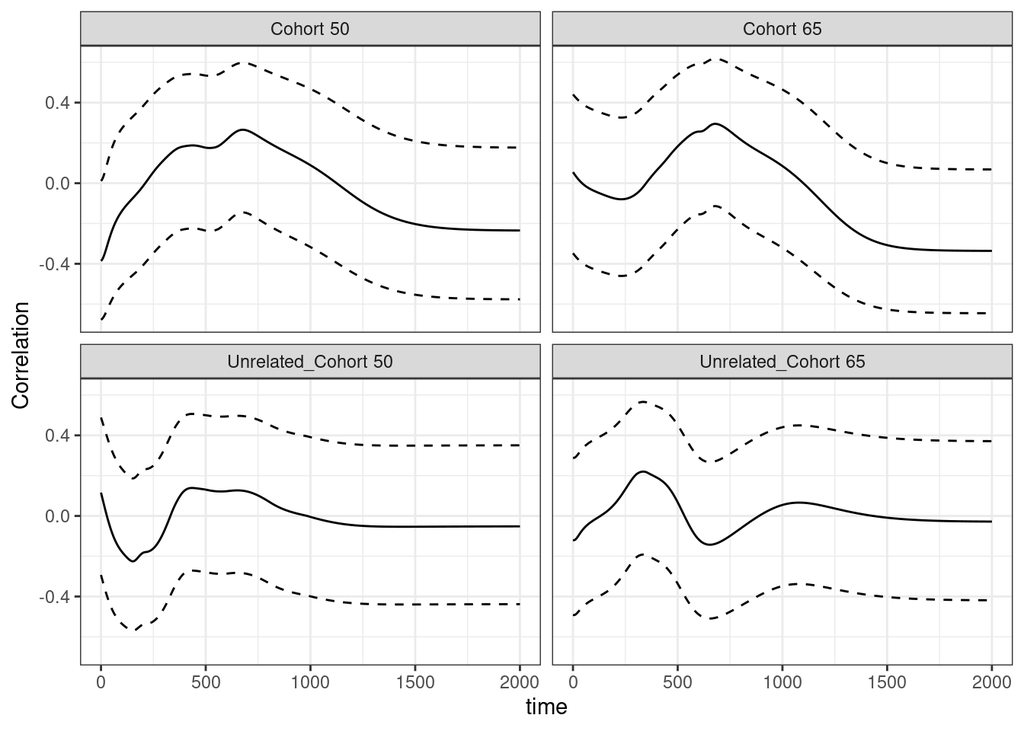

```r
## Default is no bands
plot(corr_ci, ciBands = TRUE)
```

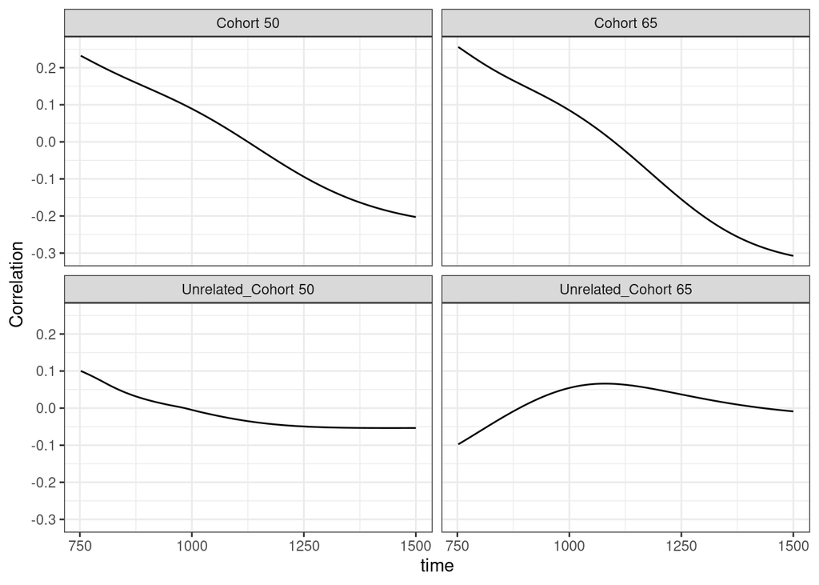

```r
## Narrow in on a particular window
plot(corr_ci, window = c(750, 1500))
```

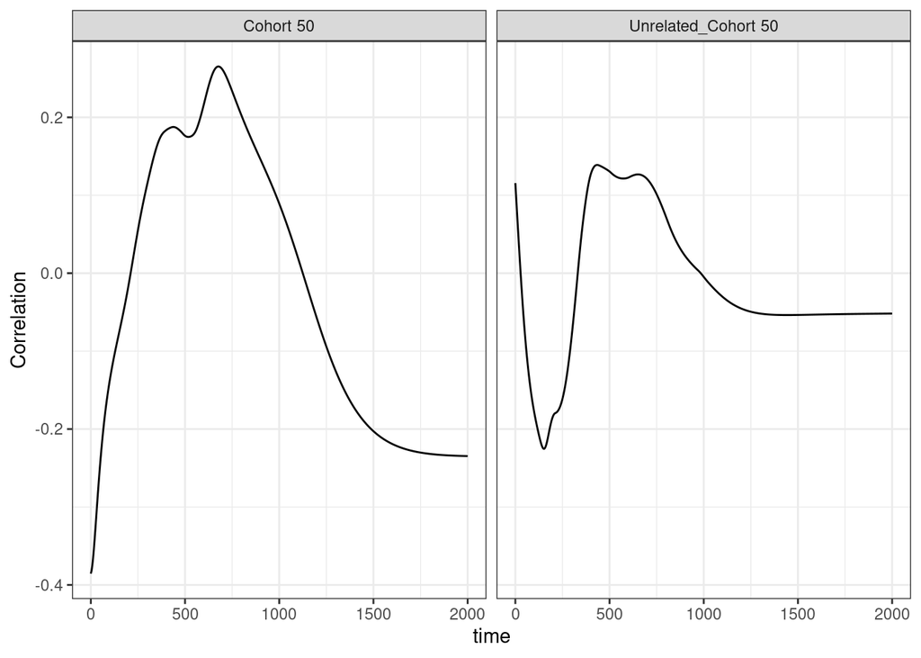

```r
## Utilizing data.table syntax
plot(corr_ci[Group2 == "50", ])
```

## Extension to non-vwp data

Whereas the original implementation of `bdots` was designed to deal with time series of equidistant samples of proportional fixation data, we are now able to address generalized time-series data along with trial-level data from the VWP. To illustrate this first case, here is some rat data I got from patrick, depicting data for the 451LuBR cell line (metastatic melanoma) growth in mice with five treatment groups.

```r
dat <- fread("~/projects/tumr/Analytic-DeIdentified_GJZ16-091_.csv")
dat <- dat[Volume != 0, ] # should incorporate this into expCurve
fit <- bdotsFit(data = dat,
                subject = "ID",
                time = "Day",
                y = "Volume",
                group = "Treatment",
                curveType = expCurve())
```